# Rod Preprocessing + Models

Rod Rosales

11/10/2021

#Libraries

```r
library(cluster)
library(caret)
library(rpart)
library(rattle)
library(factoextra)
library(dendextend)
library(tm)
library(gridExtra)
```

```r
library(stringr)
library(tidyr)
library(rpart.plot)
library(C50)
library(textclean)
library("naniar")
library(plyr)
library(dplyr)
library(arules)
library(arulesViz)
library(caTools)
library(stats)
library(ggfortify)
```

#### Pre-Processing

#1) Loading Music Genre Data

```r
Music_Gen <- read.csv("C:/Users/rod_r/OneDrive/Desktop/Syracuse Classes/Fall 2021/IST 707 Data Analytics/Project/music_genre.csv", encoding='UTF-8')
```

#2) Rename Columns

```r
colnames(Music_Gen) <- c("ID", "Artist", "Song", "Popularity", "Acoustics", "Danceability", "Duration_ms","Energy", "Instrumentalness", "Key", "Liveness", "Loudness", "Mode", "Lyrics", "Tempo","Obtained_Date", "Valence", "Genre")
```

#3) Remove Entries with values we can’t work with

```r
Music_Gen <-
  Music_Gen %>%
  mutate_if(is.numeric, ~replace(., . == -1, NA))
Music_Gen <-
  Music_Gen %>%
  mutate_if(is.numeric, ~replace(., . == 0, NA))
Music_Gen <-
  Music_Gen %>%
  mutate_if(is.factor, ~replace(., . == "empty_field", NA))
```

#4) Recharacterize Character Variables for statistics

```r
Music_Gen$ID <- as.factor(Music_Gen$ID)
Music_Gen$Artist <- as.factor(Music_Gen$Artist)
Music_Gen$Song <- as.factor(Music_Gen$Song)
Music_Gen$Key <- as.factor(Music_Gen$Key)
Music_Gen$Mode <- as.factor(Music_Gen$Mode)
Music_Gen$Genre <- as.factor(Music_Gen$Genre)
Music_Gen$Tempo <- as.numeric(Music_Gen$Tempo)
```

#5) Remove Entries with NA Values

```r
Music_Gen <- na.omit(Music_Gen)
```

#6) Index the ID numbers

```r
rownames(Music_Gen)<-Music_Gen$ID
```

#7) Get Rid of Id, Artist, and non numerical values

```r
New_Music_Gen <- Music_Gen[,-1:-3]
New_Music_Gen$Key <- NULL
New_Music_Gen$Mode <- NULL
New_Music_Gen$Genre <- NULL
Music_Gen$Obtained_Date <- NULL
```

#### Pre-Processing END

#############################Aproproi Algorithm#############################

#1) Loading Music Genre Data

```r
Music_Gen <- read.csv("C:/Users/rod_r/OneDrive/Desktop/Syracuse Classes/Fall 2021/IST 707 Data Analytics/Project/music_genre.csv", encoding='UTF-8')
```

```r
View(Music_Gen)
str(Music_Gen)
```

```
## 'data.frame':    50005 obs. of  18 variables:
##  $ instance_id     : num  32894 46652 30097 62177 24907 ...
##  $ artist_name     : chr  "Röyksopp" "Thievery Corporation" "Dillon Francis" "Dubloadz" ...
##  $ track_name      : chr  "Röyksopp's Night Out" "The Shining Path" "Hurricane" "Nitro" ...
##  $ popularity      : num  27 31 28 34 32 47 46 43 39 22 ...
##  $ acousticness    : num  0.00468 0.0127 0.00306 0.0254 0.00465 ...
##  $ danceability    : num  0.652 0.622 0.62 0.774 0.638 0.755 0.572 0.809 0.509 0.578 ...
##  $ duration_ms     : num  -1 218293 215613 166875 222369 ...
##  $ energy          : num  0.941 0.89 0.755 0.7 0.587 0.731 0.803 0.706 0.921 0.731 ...
##  $ instrumentalness: num  7.92e-01 9.50e-01 1.18e-02 2.53e-03 9.09e-01 8.54e-01 7.74e-06 9.03e-01 2.76e-04 1.12e-02 ...
##  $ key             : chr  "A#" "D" "G#" "C#" ...
##  $ liveness        : num  0.115 0.124 0.534 0.157 0.157 0.216 0.106 0.0635 0.178 0.111 ...
##  $ loudness        : num  -5.2 -7.04 -4.62 -4.5 -6.27 ...
##  $ mode            : chr  "Minor" "Minor" "Major" "Major" ...
##  $ speechiness     : num  0.0748 0.03 0.0345 0.239 0.0413 0.0412 0.351 0.0484 0.268 0.173 ...
##  $ tempo           : chr  "100.889" "115.00200000000001" "127.994" "128.014" ...
##  $ obtained_date   : chr  "4-Apr" "4-Apr" "4-Apr" "4-Apr" ...
##  $ valence         : num  0.759 0.531 0.333 0.27 0.323 0.614 0.23 0.761 0.273 0.203 ...
##  $ music_genre     : chr  "Electronic" "Electronic" "Electronic" "Electronic" ...
```

#2) Rename Columns

```r
colnames(Music_Gen) <- c("ID", "Artist", "Song", "Popularity", "Acoustics", "Danceability", "Duration_ms","Energy", "Instrumentalness", "Key", "Liveness", "Loudness", "Mode", "Lyrics", "Tempo","Obtained_Date", "Valence", "Genre")
```

#3) Remove Entries with values we can’t work with

```r
Music_Gen <-
  Music_Gen %>%
  mutate_if(is.numeric, ~replace(., . == -1, NA))
Music_Gen <-
  Music_Gen %>%
  mutate_if(is.numeric, ~replace(., . == 0, NA))
Music_Gen <-
  Music_Gen %>%
  mutate_if(is.factor, ~replace(., . == "empty_field", NA))
Music_Gen$Tempo <- as.numeric(Music_Gen$Tempo)
```

#4) Remove Entries with NA Values

```r
Music_Gen <- na.omit(Music_Gen)
```

#5) Index the ID numbers

```r
rownames(Music_Gen)<-Music_Gen$ID
```

#6) Get Rid of ID, Artist, and non numerical values

```r
New_Music_Gen <- Music_Gen[,-1:-3]
New_Music_Gen$Mode <- NULL
New_Music_Gen$Acoustics <- NULL
New_Music_Gen$Duration_ms <- NULL
New_Music_Gen$Loudness <- NULL
New_Music_Gen$Lyrics <- NULL
New_Music_Gen$Liveness <- NULL
New_Music_Gen$Obtained_Date <- NULL
```

```r
View(Music_Gen)
str(Music_Gen)
```

```
## 'data.frame':    27909 obs. of  18 variables:
##  $ ID              : num  46652 30097 62177 24907 43760 ...
##  $ Artist          : chr  "Thievery Corporation" "Dillon Francis" "Dubloadz" "What So Not" ...
##  $ Song            : chr  "The Shining Path" "Hurricane" "Nitro" "Divide & Conquer" ...
##  $ Popularity      : num  31 28 34 32 46 43 39 22 27 31 ...
##  $ Acoustics       : num  0.0127 0.00306 0.0254 0.00465 0.0289 0.0297 0.00299 0.00934 0.0337 0.016 ...
##  $ Danceability    : num  0.622 0.62 0.774 0.638 0.572 0.809 0.509 0.578 0.513 0.66 ...
##  $ Duration_ms     : num  218293 215613 166875 222369 214408 ...
##  $ Energy          : num  0.89 0.755 0.7 0.587 0.803 0.706 0.921 0.731 0.828 0.892 ...
##  $ Instrumentalness: num  9.50e-01 1.18e-02 2.53e-03 9.09e-01 7.74e-06 9.03e-01 2.76e-04 1.12e-02 5.69e-01 6.05e-04 ...
##  $ Key             : chr  "D" "G#" "C#" "F#" ...
##  $ Liveness        : num  0.124 0.534 0.157 0.157 0.106 0.0635 0.178 0.111 0.109 0.163 ...
##  $ Loudness        : num  -7.04 -4.62 -4.5 -6.27 -4.29 ...
##  $ Mode            : chr  "Minor" "Major" "Major" "Major" ...
##  $ Lyrics          : num  0.03 0.0345 0.239 0.0413 0.351 0.0484 0.268 0.173 0.0609 0.0645 ...
##  $ Tempo           : num  115 128 128 145 150 ...
##  $ Obtained_Date   : chr  "4-Apr" "4-Apr" "4-Apr" "4-Apr" ...
##  $ Valence         : num  0.531 0.333 0.27 0.323 0.23 0.761 0.273 0.203 0.0591 0.111 ...
##  $ Genre           : chr  "Electronic" "Electronic" "Electronic" "Electronic" ...
##  - attr(*, "na.action")= 'omit' Named int [1:22096] 1 6 11 14 17 24 25 33 36 37 ...
##   ..- attr(*, "names")= chr [1:22096] "1" "6" "11" "14" ...
```

#7) Range of Danceability

```r
range(Music_Gen$Danceability)
```

```
## [1] 0.0596 0.9860
```

#8) Range of Popularity

```r
range(Music_Gen$Popularity)
```

```
## [1]  1 99
```

#9) Range of Energy

```r
range(Music_Gen$Energy)
```

```
## [1] 0.000792 0.999000
```

#10) Range of Tempo

```r
range(Music_Gen$Tempo)
```

```
## [1]  34.347 220.276
```

#11) Range of Instrumentalness

```r
range(Music_Gen$Instrumentalness)
```

```
## [1] 0.000001 0.996000
```

#13) Range of Valence

```r
range(Music_Gen$Valence)
```

```
## [1] 0.0205 0.9920
```

#14) Discretize Variables

```r
New_Music_Gen$Danceability <- cut(New_Music_Gen$Danceability, breaks = c(.01,.25,.50,.75,Inf),labels=c("Not Danceable","Head-Bobber"," Danceable","Highly Danceable"))
New_Music_Gen$Popularity <- cut(New_Music_Gen$Popularity, breaks = c(1,30,50,70,90,Inf),labels=c("Niche","Not Popular","Somwhat Popular","Popular","Mainstream"))
New_Music_Gen$Energy <- cut(New_Music_Gen$Energy, breaks = c(.0005,.30,.60,.90,Inf),labels=c("Low","Moderate", "Upbeat", "Energetic"))
New_Music_Gen$Tempo <- cut(New_Music_Gen$Tempo, breaks = c(30,50,70,90,150,Inf),labels=c("Grave","Adagietto", "Moderato", "Allegro", "Prestissimo"))
New_Music_Gen$Instrumentalness <- cut(New_Music_Gen$Instrumentalness, breaks = c(.0,.10,.30,.60,.90,Inf),labels=c("Acapella","Low Instruments", "Moderate", "Instruments", "Full Instrumental"))
New_Music_Gen$Valence <- cut(New_Music_Gen$Valence, breaks = c(.01,.30,.50,.70,.90,Inf),labels=c("Depressing","Angry","Moderate","cheerful","Euphoric"))
```

```r
View(New_Music_Gen)
str(New_Music_Gen)
```

```
## 'data.frame':    27909 obs. of  8 variables:
##  $ Popularity      : Factor w/ 5 levels "Niche","Not Popular",..: 2 1 2 2 2 2 2 1 1 2 ...
##  $ Danceability    : Factor w/ 4 levels "Not Danceable",..: 3 3 4 3 3 4 3 3 3 3 ...
##  $ Energy          : Factor w/ 4 levels "Low","Moderate",..: 3 3 3 2 3 3 4 3 3 3 ...
##  $ Instrumentalness: Factor w/ 5 levels "Acapella","Low Instruments",..: 5 1 1 5 1 5 1 1 3 1 ...
##  $ Key             : chr  "D" "G#" "C#" "F#" ...
##  $ Tempo           : Factor w/ 5 levels "Grave","Adagietto",..: 4 4 4 4 4 4 4 4 5 4 ...
##  $ Valence         : Factor w/ 5 levels "Depressing","Angry",..: 3 2 1 2 1 4 1 1 1 1 ...
##  $ Genre           : chr  "Electronic" "Electronic" "Electronic" "Electronic" ...
```

#15)Recode:

```r
New_Music_Gen$Popularity=dplyr::recode(New_Music_Gen$Popularity, YES="married=YES", NO="married=NO")
New_Music_Gen$Danceability=dplyr::recode(New_Music_Gen$Danceability, YES="car=YES", NO="car=NO")
New_Music_Gen$Energy=dplyr::recode(New_Music_Gen$Energy, YES="save_act=YES", NO="save_act=NO")
New_Music_Gen$Instrumentalness=dplyr::recode(New_Music_Gen$Instrumentalness, YES="current_act=YES", NO="current_act=NO")
New_Music_Gen$Tempo=dplyr::recode(New_Music_Gen$Tempo, YES="mortgage=YES", NO="mortgage=NO")
New_Music_Gen$Valence=dplyr::recode(New_Music_Gen$Valence, YES="pep=YES", NO="pep=NO")
New_Music_Gen$Genre=dplyr::recode(New_Music_Gen$Genre, YES="pep=YES", NO="pep=NO")
New_Music_Gen$Key=dplyr::recode(New_Music_Gen$Key, YES="pep=YES", NO="pep=NO")
```

#16) Load transformed data into apriori algorithm

```r
MyRules = apriori(New_Music_Gen, parameter = list(supp = 0.001, conf = 0.9, maxlen = 4))
```

```
## Apriori
##
## Parameter specification:
##  confidence minval smax arem  aval originalSupport maxtime support minlen
##         0.9    0.1    1 none FALSE            TRUE       5   0.001      1
##  maxlen target  ext
##       4  rules TRUE
##
## Algorithmic control:
##  filter tree heap memopt load sort verbose
##     0.1 TRUE TRUE  FALSE TRUE    2    TRUE
##
## Absolute minimum support count: 27
##
## set item appearances ...[0 item(s)] done [0.00s].
## set transactions ...[50 item(s), 27909 transaction(s)] done [0.01s].
## sorting and recoding items ... [48 item(s)] done [0.00s].
## creating transaction tree ... done [0.01s].
## checking subsets of size 1 2 3 4
```

```
##  done [0.03s].
## writing ... [1248 rule(s)] done [0.00s].
## creating S4 object  ... done [0.00s].
```

#17) Sort and inspect(myRules)

```r
MyRules.sorted <- sort(MyRules, by="lift")
inspect(MyRules.sorted)
```

```
##        lhs                                     rhs                              support confidence    coverage     lift count
## [1]    {Energy=Low,
##         Key=F#,
##         Tempo=Adagietto}                    => {Genre=Classical}            0.001003261  0.9032258 0.001110753 7.189997    28
## [2]    {Popularity=Not Popular,
##         Danceability=Not Danceable,
##         Energy=Low}                         => {Genre=Classical}            0.027303021  0.9017751 0.030276972 7.178449   762
## [3]    {Popularity=Not Popular,
##         Instrumentalness=Full Instrumental,
##         Tempo=Adagietto}                    => {Genre=Classical}            0.004550503  0.9007092 0.005052134 7.169964   127
## [4]    {Popularity=Niche,
##         Danceability=Highly Danceable,
##         Energy=Energetic}                   => {Genre=Electronic}           0.001146584  0.9142857 0.001254076 6.660611    32
## [5]    {Key=F#,
##         Tempo=Adagietto,
##         Genre=Classical}                    => {Energy=Low}                 0.001003261  1.0000000 0.001003261 5.084533    28
## [6]    {Key=G#,
##         Tempo=Adagietto,
##         Genre=Classical}                    => {Energy=Low}                 0.001074922  1.0000000 0.001074922 5.084533    30
## [7]    {Key=G#,
##         Tempo=Adagietto,
##         Valence=Depressing}                 => {Energy=Low}                 0.001361568  1.0000000 0.001361568 5.084533    38
## [8]    {Danceability=Not Danceable,
##         Instrumentalness=Full Instrumental,
##         Tempo=Adagietto}                    => {Energy=Low}                 0.003547243  1.0000000 0.003547243 5.084533    99
## [9]    {Instrumentalness=Full Instrumental,
##         Key=G,
##         Tempo=Adagietto}                    => {Energy=Low}                 0.001003261  1.0000000 0.001003261 5.084533    28
## [10]   {Key=A,
##         Tempo=Adagietto,
##         Genre=Classical}                    => {Energy=Low}                 0.001254076  1.0000000 0.001254076 5.084533    35
## [11]   {Key=G,
##         Tempo=Adagietto,
##         Genre=Classical}                    => {Energy=Low}                 0.001433229  1.0000000 0.001433229 5.084533    40
## [12]   {Tempo=Adagietto,
##         Valence=Angry,
##         Genre=Classical}                    => {Energy=Low}                 0.001110753  1.0000000 0.001110753 5.084533    31
## [13]   {Popularity=Niche,
##         Tempo=Adagietto,
##         Genre=Classical}                    => {Energy=Low}                 0.003869719  0.9908257 0.003905550 5.037886   108
```

[output cut: 3536 more lines]

```
## [1244] {Danceability=Highly Danceable,
##         Energy=Upbeat,
##         Valence=Depressing}                 => {Tempo=Allegro}              0.006270379  0.9020619 0.006951163 1.399891   175
## [1245] {Danceability=Highly Danceable,
##         Energy=Moderate,
##         Genre=Electronic}                   => {Tempo=Allegro}              0.007918593  0.9020408 0.008778530 1.399859   221
## [1246] {Danceability=Highly Danceable,
##         Instrumentalness=Low Instruments,
##         Valence=cheerful}                   => {Tempo=Allegro}              0.001648214  0.9019608 0.001827368 1.399734    46
## [1247] {Danceability=Highly Danceable,
##         Key=F#,
##         Genre=Electronic}                   => {Tempo=Allegro}              0.001970690  0.9016393 0.002185675 1.399236    55
## [1248] {Instrumentalness=Moderate,
##         Valence=Depressing,
##         Genre=Alternative}                  => {Tempo=Allegro}              0.001289906  0.9000000 0.001433229 1.396692    36
```

#############################Aproproi Algorithm END#############################

###### K-Means Cluster Analysis (Music Popularity)

#1) Loading Music Genre Data

```r
Music_Gen <- read.csv("C:/Users/rod_r/OneDrive/Desktop/Syracuse Classes/Fall 2021/IST 707 Data Analytics/Project/music_genre.csv", encoding='UTF-8')
```

#2) Rename Columns

```r
colnames(Music_Gen) <- c("ID", "Artist", "Song", "Popularity", "Acoustics", "Danceability", "Duration_ms","Energy", "Instrumentalness", "Key", "Liveness", "Loudness", "Mode", "Lyrics", "Tempo","Obtained_Date", "Valence", "Genre")
```

#3) Remove Entries with values we can’t work with

```r
Music_Gen <-
Music_Gen %>%
  mutate_if(is.numeric, ~replace(., . == -1, NA))

Music_Gen <-
Music_Gen %>%
  mutate_if(is.numeric, ~replace(., . == 0, NA))

Music_Gen <-
Music_Gen %>%
  mutate_if(is.factor, ~replace(., . == "empty_field", NA))
Music_Gen$Tempo <- as.numeric(Music_Gen$Tempo)
```

#4) Remove Entries with NA Values

```r
Music_Gen <- na.omit(Music_Gen)
```

#5) Index the ID numbers

```r
rownames(Music_Gen)<-Music_Gen$ID
```

#6) Get Rid of Id, Artist, and non numerical values

```r
New_Music_Gen <- Music_Gen[,-1:-3]
New_Music_Gen$Instrumentalness <- NULL
New_Music_Gen$Key <- NULL
New_Music_Gen$Genre <- NULL
New_Music_Gen$Mode <- NULL
New_Music_Gen$Acoustics <- NULL
New_Music_Gen$Duration_ms <- NULL
New_Music_Gen$Loudness <- NULL
New_Music_Gen$Lyrics <- NULL
New_Music_Gen$Liveness <- NULL
New_Music_Gen$Obtained_Date <- NULL
```

#7) WSS Plot create function and run

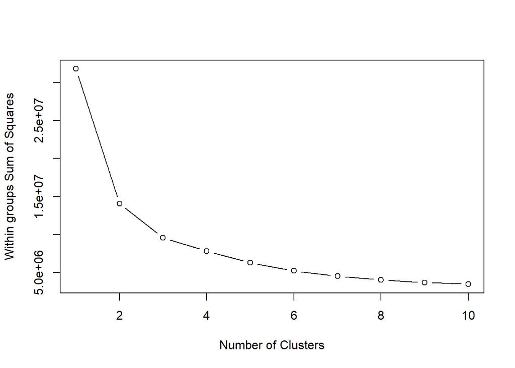

```r
wssplot <- function(data, nc=10, seed=1234)
{
  wss <- (nrow(data)-1)*sum(apply(data,2,var))
  for (i in 2:nc){
  set.seed(seed)
  wss[i] <- sum(kmeans(data,centers=i)$withinss)}
  plot(1:nc, wss, type="b", xlab= "Number of Clusters",
  ylab = "Within groups Sum of Squares")
}
wssplot(New_Music_Gen)
```

#8) K-means Cluster / Plot / Centers

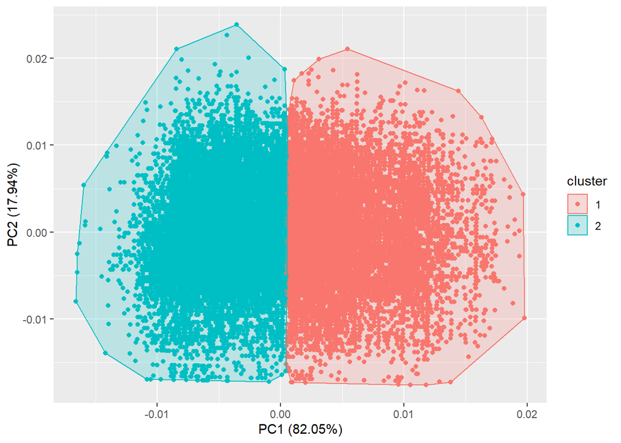

```r
KM = kmeans(New_Music_Gen,2)
autoplot(KM, New_Music_Gen, frame= TRUE)
```

```r
KM$centers
```

```
##   Popularity Danceability    Energy     Tempo   Valence
## 1   42.30905    0.5302012 0.6449086 146.82414 0.4471412
## 2   42.15159    0.5381648 0.5219094  96.11958 0.4257968
```

K-Means Cluster END

Test And Train [Still Working on This]

#1) Split Data into Test and Training (Popularity)

```r
split = sample.split(New_Music_Gen$Popularity, SplitRatio = .80)
train = subset(New_Music_Gen, split == TRUE)
test = subset(New_Music_Gen, split == FALSE)
```

Test And Trai END